# Cereal Market

## 5.2 Does seasonality affect units sold?

We would like to see if the means differ between each flavor per quarter. This will allow us to identify which quarter we are the strongest in sales. In order to do this we will formulate the following hypothesis:

Ho muQ1=muQ2=muQ3=muQ4 H1: All mu’s are not equal

```r
tbl = table(mtp$qrt,mtp$flavor)
tbl
```

```
##
##      CINNAMON TOAST COCOA FRUIT REGULAR TOASTED
##   Q1            488   442   469    2195    1770
##   Q2            530   455   564    2436    1922
##   Q3            463   597   666    2387    1841
##   Q4            353   407   493    1798    1574
```

```r
chisq.test(tbl, correct = FALSE)
```

```
##
##  Pearson's Chi-squared test
##
## data:  tbl
## X-squared = 64.047, df = 12, p-value = 4.089e-09
```

At the 5% level of significance there is sufficient evidence that the proportion of units sold differ by quarter.

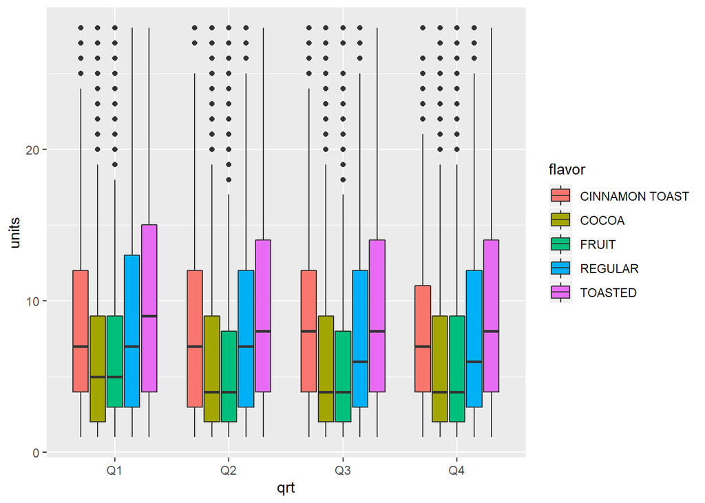

```r
mtp %>%
  group_by(flavor) %>%
  ggplot(mapping = aes(x = qrt, y = units, fill = flavor)) +
  geom_boxplot()
```